# Factors Influencing Term Deposit Subscription

Anthony Mallamaci

2025-10-14

# Introduction

Variable list and definitions:

1. age (numeric) — Age of the client (in years).
2. job (categorical) — Type of job (e.g., admin., unemployed, management, technician, etc.).
3. marital (categorical) — Marital status (married, divorced/widowed, single).
4. education (categorical) — Education level (primary, secondary, tertiary, unknown).
5. default (binary categorical) — Does the client have credit in default? (yes, no).
6. balance (numeric) — Average yearly balance of the client’s account (in euros).
7. housing (binary categorical) — Has a housing loan? (yes, no).
8. loan (binary categorical) — Has a personal loan? (yes, no).

Last contact of current campaign:

9. contact (categorical) — Communication type (telephone, cellular, unknown).
10. day (categorical) — Day of the month of last contact.
11. month (categorical) — Month of last contact (jan–dec).
12. duration (numeric) — Duration of last contact in seconds
13. campaign (numeric) — Number of contacts performed during this campaign for the client (includes last contact).
14. pdays (numeric) — Days since client was last contacted in a previous campaign (-1 means not previously contacted).
15. previous (numeric) — Number of contacts performed before this campaign for this client.
16. poutcome (categorical) — Outcome of the previous marketing campaign (success, failure, other, unknown).

Target variable:

17. y (binary categorical) — Has the client subscribed to a term deposit? (yes, no).

This analysis examines factors influencing a client’s subscription to a term deposit (y) for both association and predictive purposes. The goal is to identify which client and campaign features are associated with subscription probability and to build a predictive model for new clients. In addition to the classification analysis, this report also explores a secondary question using regression: Do the variables Marital and Education help predict a client’s average yearly account balance? Together, these analyses provide a more comprehensive understanding of client behavior—both in terms of their likelihood to subscribe and their financial standing.

# Methodology

This report employs statistical modeling techniques to analyze client behavior and predict key outcomes related to term deposit subscriptions and account balances. The methodology is divided into two main parts: a logistic regression model for classification and a multiple linear regression model for quantitative prediction.

## Logistic Regression Model

Logistic regression is used to model the binary response variable, whether a client subscribes to a term deposit (y = yes or no). This model estimates the probability of subscription based on client demographics, financial status, and campaign characteristics. Predictors include variables such as marital status, education, housing loan, personal loan, contact method, month, and call duration. The model assumes independence of observations, linearity of the logit for continuous variables, and no multicollinearity among predictors. Variance Inflation Factors (VIF) were examined to confirm that multicollinearity was not an issue, ensuring stable coefficient estimates.

Model performance was evaluated using the Receiver Operating Characteristic (ROC) curve and the Area Under the Curve (AUC), which measure the model’s ability to distinguish between clients who subscribed and those who did not. The optimal cutoff probability was determined to balance sensitivity and specificity, ensuring practical predictive accuracy.

## Multiple Linear Regression Model

This analysis examines factors associated with a client’s average yearly account balance. Specifically, it investigates whether marital status and education level are significantly related to balance, aiming to determine if demographic factors influence clients’ financial standing. The goal is to identify patterns that may help explain variations in balance across different groups within the dataset.

By combining logistic and linear regression, this methodology allows for a comprehensive understanding of both the likelihood of subscription and the financial characteristics of clients, supporting more informed decision-making in targeted marketing strategies.

# EDA and Feature Engineering

Exploratory Data Analysis (EDA) was conducted to better understand the dataset’s structure, identify potential data quality issues, and inform feature engineering decisions. The goal was to create meaningful, interpretable variables that improve model performance while maintaining statistical soundness for regression analysis.

## Handling Missing Values

The dataset contained missing values primarily in the education, contact, and poutcome variables. Since these are categorical, missing entries were imputed using the label “unknown,” preserving data integrity without introducing bias. This approach is appropriate given the relatively low proportion of missingness and maintains consistency with how unknown categories are treated in similar marketing datasets. No missing values were observed in key numerical variables such as age, balance, or duration.

## Single Variable Distribution

```r
# Read in dataset
url <- "https://raw.githubusercontent.com/Antho028/MySTA551/refs/heads/main/Bank.Test.csv"
mydata <- read.csv(url)






#ggplots

# Load libraries
library(ggplot2)
library(dplyr)
library(readr)
library(ggridges)

# Read data
bank <- read_csv("Bank.Test.csv")
head(bank)
```

```
# A tibble: 6 × 17
    age job        marital education default balance housing loan  contact   day
  <dbl> <chr>      <chr>   <chr>     <chr>     <dbl> <chr>   <chr> <chr>   <dbl>
1    30 unemployed married primary   no         1787 no      no    cellul…    19
2    33 services   married secondary no         4789 yes     yes   cellul…    11
3    35 management single  tertiary  no         1350 yes     no    cellul…    16
4    30 management married tertiary  no         1476 yes     yes   unknown     3
5    59 blue-coll… married secondary no            0 yes     no    unknown     5
6    35 management single  tertiary  no          747 no      no    cellul…    23
# ℹ 7 more variables: month <chr>, duration <dbl>, campaign <dbl>, pdays <dbl>,
#   previous <dbl>, poutcome <chr>, y <chr>
```

```r
# Descriptive Statistics
summary(bank)
```

```
      age            job              marital           education
 Min.   :19.00   Length:4521        Length:4521        Length:4521
 1st Qu.:33.00   Class :character   Class :character   Class :character
 Median :39.00   Mode  :character   Mode  :character   Mode  :character
 Mean   :41.17
 3rd Qu.:49.00
 Max.   :87.00
   default             balance        housing              loan
 Length:4521        Min.   :-3313   Length:4521        Length:4521
 Class :character   1st Qu.:   69   Class :character   Class :character
 Mode  :character   Median :  444   Mode  :character   Mode  :character
                    Mean   : 1423
                    3rd Qu.: 1480
                    Max.   :71188
   contact               day           month              duration
 Length:4521        Min.   : 1.00   Length:4521        Min.   :   4
 Class :character   1st Qu.: 9.00   Class :character   1st Qu.: 104
 Mode  :character   Median :16.00   Mode  :character   Median : 185
                    Mean   :15.92                      Mean   : 264
                    3rd Qu.:21.00                      3rd Qu.: 329
                    Max.   :31.00                      Max.   :3025
    campaign          pdays           previous         poutcome
 Min.   : 1.000   Min.   : -1.00   Min.   : 0.0000   Length:4521
 1st Qu.: 1.000   1st Qu.: -1.00   1st Qu.: 0.0000   Class :character
 Median : 2.000   Median : -1.00   Median : 0.0000   Mode  :character
 Mean   : 2.794   Mean   : 39.77   Mean   : 0.5426
 3rd Qu.: 3.000   3rd Qu.: -1.00   3rd Qu.: 0.0000
 Max.   :50.000   Max.   :871.00   Max.   :25.0000
      y
 Length:4521
 Class :character
 Mode  :character
```

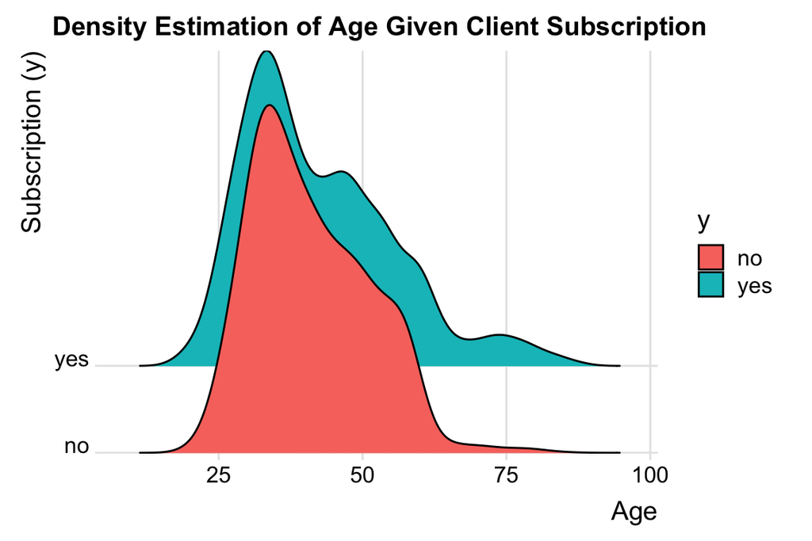

```r
# Age vs Subscription
ggplot(bank, aes(x = age, y = y, fill = y)) +
  geom_density_ridges_gradient(scale = 4) +
  theme_ridges() +
  scale_y_discrete(expand = c(0.01, 0)) +
  scale_x_continuous(expand = c(0.08, 0)) +
  labs(x = "Age", y = "Subscription (y)") +
  ggtitle("Density Estimation of Age Given Client Subscription") +
  theme(plot.title = element_text(hjust = 0.5))
```

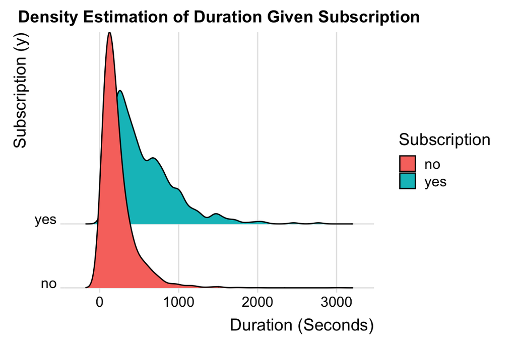

```r
# Duration vs Subscription
ggplot(bank, aes(x = duration, y = y, fill = y)) +
  geom_density_ridges_gradient(scale = 4) +
  theme_ridges() +
  scale_y_discrete(expand = c(0.01, 0)) +
  scale_x_continuous(expand = c(0.08, 0)) +
  labs(x = "Duration (Seconds)", y = "Subscription (y)", fill = "Subscription") +
  ggtitle("Density Estimation of Duration Given Subscription") +
  theme(plot.title = element_text(hjust = 0.5))
```

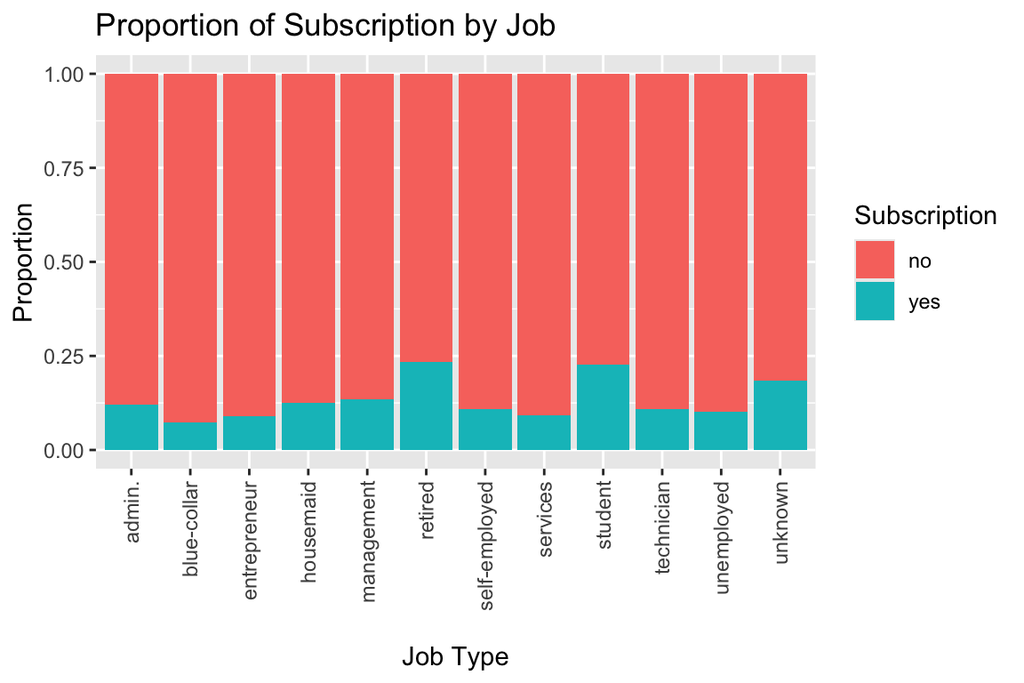

```r
# Job vs Subscription
ggplot(bank, aes(x = job, fill = y)) +
  geom_bar(position = "fill") +
  labs(x = "Job Type", y = "Proportion", title = "Proportion of Subscription by Job", fill = "Subscription") +
  theme(
    axis.text.x = element_text(angle = 90, vjust = 0.5, hjust = 1),
    axis.title.x = element_text(margin = margin(t = 15))
  )
```

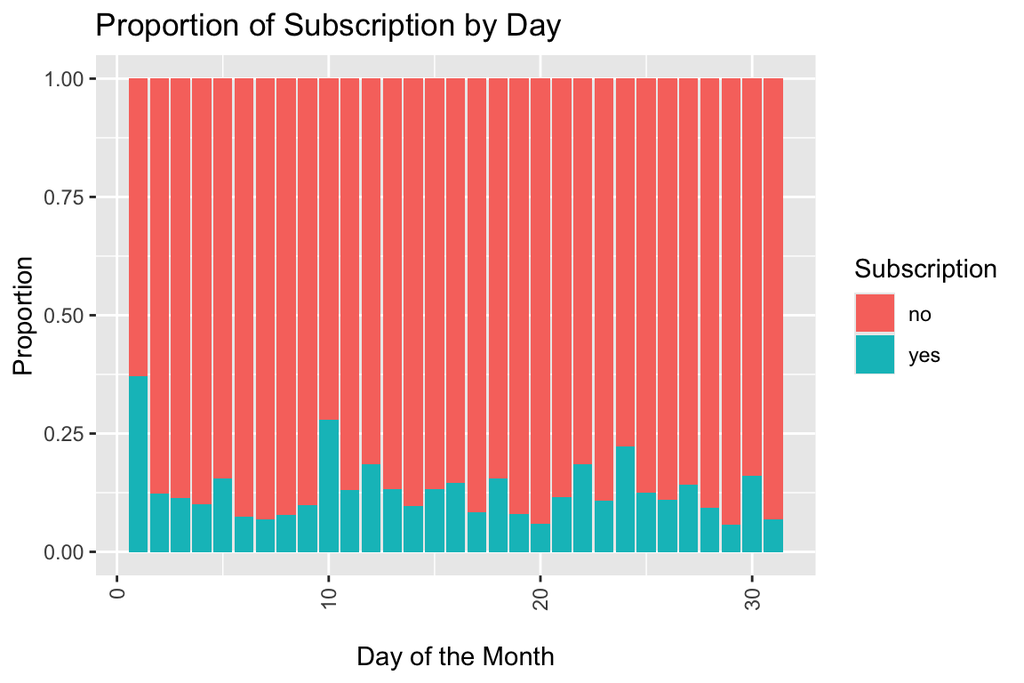

```r
# Day vs Subscription
ggplot(bank, aes(x = day, fill = y)) +
  geom_bar(position = "fill") +
  labs(x = "Day of the Month", y = "Proportion", title = "Proportion of Subscription by Day", fill = "Subscription") +
  theme(
    axis.text.x = element_text(angle = 90, vjust = 0.5, hjust = 1),
    axis.title.x = element_text(margin = margin(t = 15))
  )
```

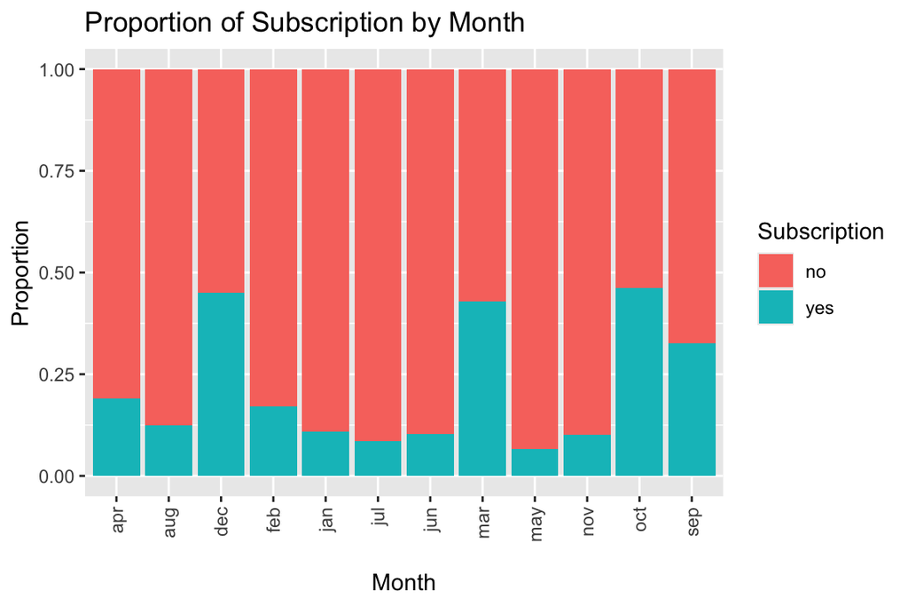

```r
# Month vs Subscription
ggplot(bank, aes(x = month, fill = y)) +
  geom_bar(position = "fill") +
  labs(x = "Month", y = "Proportion", title = "Proportion of Subscription by Month", fill = "Subscription") +
  theme(
    axis.text.x = element_text(angle = 90, vjust = 0.5, hjust = 1),
    axis.title.x = element_text(margin = margin(t = 15))
  )
```

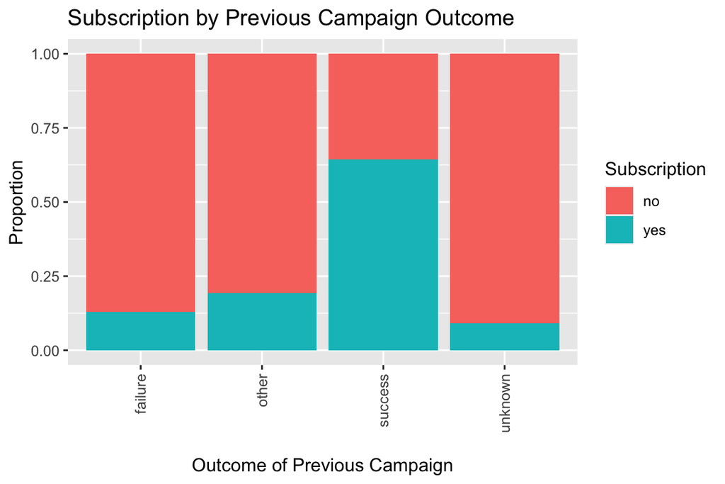

```r
# Previous Campaign Outcome vs Subscription
ggplot(bank, aes(x = poutcome, fill = y)) +
  geom_bar(position = "fill") +
  labs(x = "Outcome of Previous Campaign", y = "Proportion", title = "Subscription by Previous Campaign Outcome", fill = "Subscription") +
  theme(
    axis.text.x = element_text(angle = 90, vjust = 0.5, hjust = 1),
    axis.title.x = element_text(margin = margin(t = 15))
  )
```

## Assessing Pairwise Relationships

Overall, the EDA process ensured that the data was clean, well-structured, and suitable for regression modeling, with careful consideration given to interpretability and statistical validity.

## Data Engineering

Before I could continue with Logistic, linear regression and cross validation I needed to make sure my variables were suitable for such models. First for variable y I encoded it to be 1 and 0 in replace of “Yes” and “no” respectively. Next for the remaining character variables I converted them to factors. I also found that the variable balance was heavily skewed to the right. To fix this a conducted a box and cox plot. With the lamda being close to 0 I conducted a log trasformation of the balance variable.

```r
# Read in dataset
url <- "https://raw.githubusercontent.com/Antho028/MySTA551/refs/heads/main/Bank.Test.csv"
mydata <- read.csv(url)
head(mydata)
```

```
  age         job marital education default balance housing loan  contact day
1  30  unemployed married   primary      no    1787      no   no cellular  19
2  33    services married secondary      no    4789     yes  yes cellular  11
3  35  management  single  tertiary      no    1350     yes   no cellular  16
4  30  management married  tertiary      no    1476     yes  yes  unknown   3
5  59 blue-collar married secondary      no       0     yes   no  unknown   5
6  35  management  single  tertiary      no     747      no   no cellular  23
  month duration campaign pdays previous poutcome  y
1   oct       79        1    -1        0  unknown no
2   may      220        1   339        4  failure no
3   apr      185        1   330        1  failure no
4   jun      199        4    -1        0  unknown no
5   may      226        1    -1        0  unknown no
6   feb      141        2   176        3  failure no
```

```r
summary(mydata)
```

```
      age            job              marital           education
 Min.   :19.00   Length:4521        Length:4521        Length:4521
 1st Qu.:33.00   Class :character   Class :character   Class :character
 Median :39.00   Mode  :character   Mode  :character   Mode  :character
 Mean   :41.17
 3rd Qu.:49.00
 Max.   :87.00
   default             balance        housing              loan
 Length:4521        Min.   :-3313   Length:4521        Length:4521
 Class :character   1st Qu.:   69   Class :character   Class :character
 Mode  :character   Median :  444   Mode  :character   Mode  :character
                    Mean   : 1423
                    3rd Qu.: 1480
                    Max.   :71188
   contact               day           month              duration
 Length:4521        Min.   : 1.00   Length:4521        Min.   :   4
 Class :character   1st Qu.: 9.00   Class :character   1st Qu.: 104
 Mode  :character   Median :16.00   Mode  :character   Median : 185
                    Mean   :15.92                      Mean   : 264
                    3rd Qu.:21.00                      3rd Qu.: 329
                    Max.   :31.00                      Max.   :3025
    campaign          pdays           previous         poutcome
 Min.   : 1.000   Min.   : -1.00   Min.   : 0.0000   Length:4521
 1st Qu.: 1.000   1st Qu.: -1.00   1st Qu.: 0.0000   Class :character
 Median : 2.000   Median : -1.00   Median : 0.0000   Mode  :character
 Mean   : 2.794   Mean   : 39.77   Mean   : 0.5426
 3rd Qu.: 3.000   3rd Qu.: -1.00   3rd Qu.: 0.0000
 Max.   :50.000   Max.   :871.00   Max.   :25.0000
      y
 Length:4521
 Class :character
 Mode  :character
```

```r
# Variable encoding (y variable)
mydata$y <- ifelse(mydata$y == "yes", 1, 0)

# Convert categorical variables to factors
mydata$job        <- as.factor(mydata$job)
mydata$marital    <- as.factor(mydata$marital)
mydata$default    <- as.factor(mydata$default)
mydata$loan       <- as.factor(mydata$loan)
mydata$housing    <- as.factor(mydata$housing)
mydata$education  <- as.factor(mydata$education)
mydata$contact    <- as.factor(mydata$contact)
mydata$month      <- as.factor(mydata$month)
mydata$poutcome   <- as.factor(mydata$poutcome)



# Box Cox to fix right skew of baalnce variable.
library(MASS)

# Shift the variable so all values are positive
mydata$balance_shifted <- mydata$balance + 3314

# Fit a simple linear model
bc_model <- lm(balance_shifted ~ 1, data = mydata)
any(mydata$balance_shifted < 0)
```

```
[1] FALSE
```

```r
# Perform Box-Cox transformation to find optimal lambda
bc_result <- boxcox(bc_model, lambda = seq(-2, 2, by = 0.1))
```

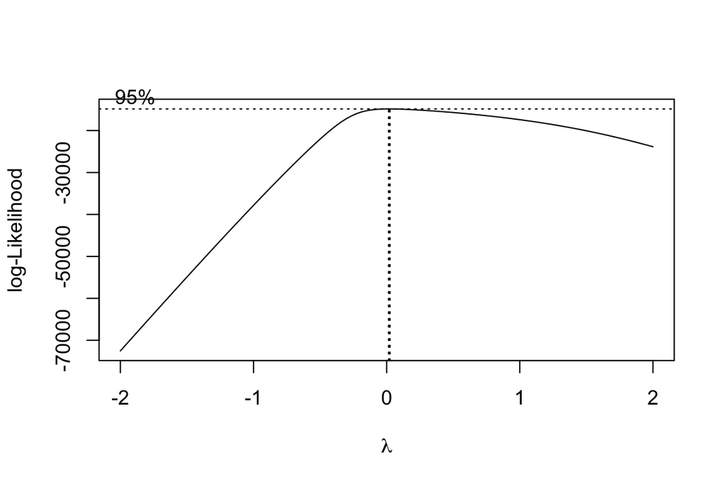

```r
# Extract the lambda with the maximum log-likelihood
lambda_opt <- bc_result$x[which.max(bc_result$y)]
cat("Optimal lambda:", lambda_opt, "\n")
```

```
Optimal lambda: 0.02020202
```

```r
# Apply the Box-Cox transformation using the optimal lambda
if (lambda_opt == 0) {
  mydata$balance_boxcox <- log(mydata$balance_shifted)
} else {
  mydata$balance_boxcox <- (mydata$balance_shifted^lambda_opt - 1) / lambda_opt
}

# Check the transformed variable
summary(mydata$balance_boxcox)
```

```
   Min. 1st Qu.  Median    Mean 3rd Qu.    Max.
  0.000   8.832   8.956   9.118   9.244  12.592
```

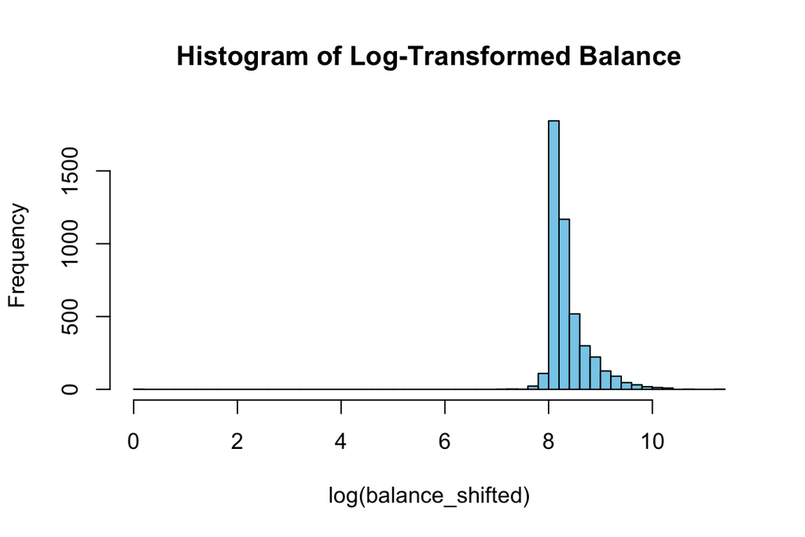

```r
mydata$balance_log <- log(mydata$balance_shifted)

# Quick check: look at the distribution
hist(mydata$balance_log,
     main = "Histogram of Log-Transformed Balance",
     xlab = "log(balance_shifted)",
     breaks = 50,
     col = "skyblue")
```

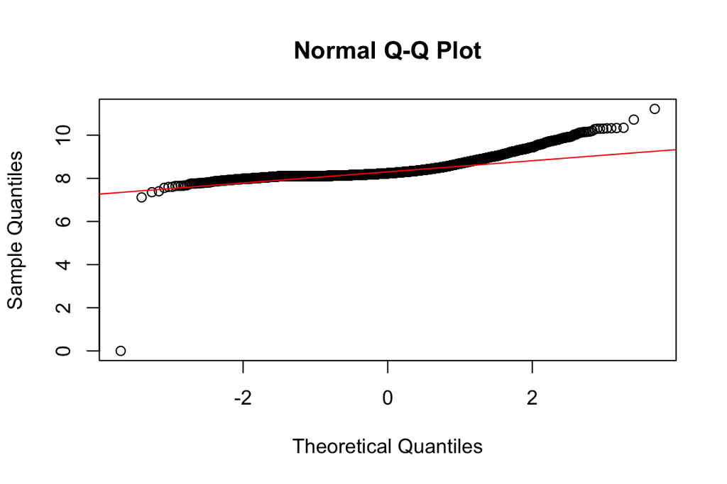

```r
qqnorm(mydata$balance_log)
qqline(mydata$balance_log, col = "red")
```

```r
# Shapiro–Wilk normality test
shapiro.test(sample(mydata$balance_log, min(5000, nrow(mydata))))
```

```
    Shapiro-Wilk normality test

data:  sample(mydata$balance_log, min(5000, nrow(mydata)))
W = 0.74524, p-value < 2.2e-16
```

Even after applying a log transformation to the balance variable, the residuals still deviate from normality. Therefore, any conclusions drawn from this model should be interpreted with caution.

# Model Building

## Linear Regression Model

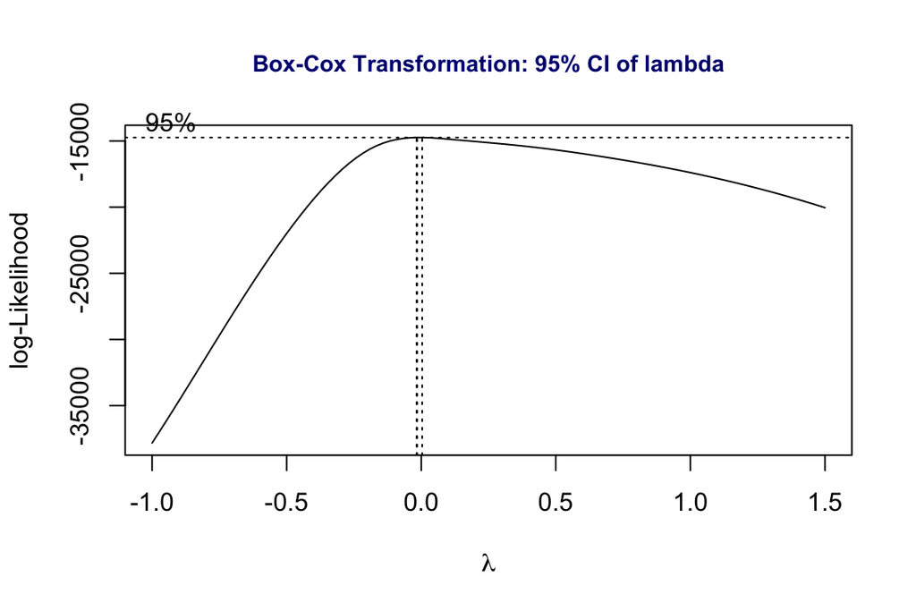

```r
# regression full model
library(knitr)
library(kableExtra)
library(car)
library(corrplot)

ini.model = lm(balance ~ marital + education, data = mydata)
#par(mfrow=c(2,2), mar=c(2,3,2,2))
#plot(ini.model)

#Shift variables with negative values
mydata$balance_shifted <- mydata$balance + 3314
mydata$pdays_shifted <- mydata$pdays + 2

library(MASS)
boxcox(balance_shifted ~ marital + education,
       data = mydata,
       lambda = seq(-1, 1.5, length = 10),
       xlab=expression(paste(lambda)))
title(main = "Box-Cox Transformation: 95% CI of lambda",
      col.main = "navy", cex.main = 0.9)
```

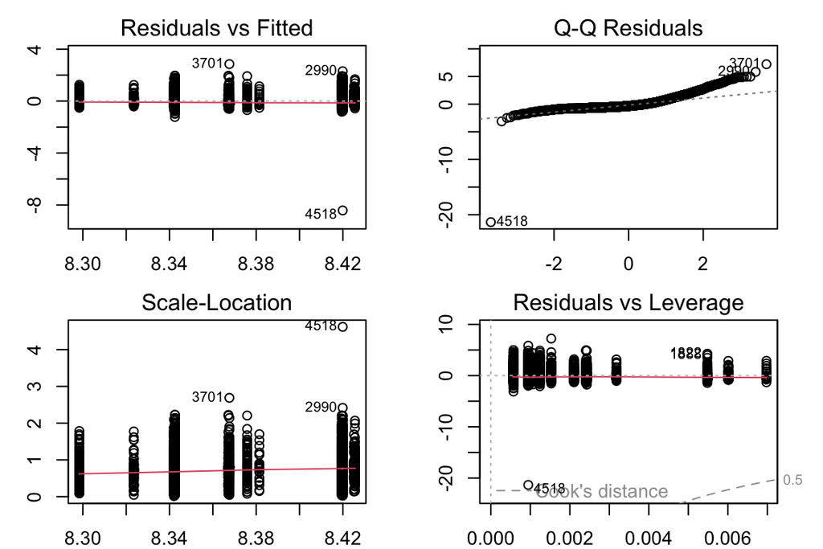

```r
#lamda is close to 0 so I will transform balance using log

mydata$balance_log <- log(mydata$balance_shifted)

# Same model with log tranformation of balance
transformed.model = lm(balance_log ~ marital + education, data = mydata)   # fit a linear model with interaction effect
par(mfrow=c(2,2), mar=c(2,3,2,2))
plot(transformed.model)
```

```r
library(knitr)
library(kableExtra)

# Stepwise model selection (backward)
final.model = step(transformed.model, direction = "backward", trace = 0)

# Display regression coefficients with white font
kable(summary(final.model)$coef,
      caption = "Summary statistics of the regression coefficients of the final model") %>%
  kable_styling(full_width = FALSE,
                position = "center",
                font_size = 13,
                bootstrap_options = c("striped", "hover")) %>%
  row_spec(0, color = "black") %>%   # white font for header
  row_spec(1:nrow(summary(final.model)$coef), color = "black")
```

Summary statistics of the regression coefficients of the final model

|  | Estimate | Std. Error | t value | Pr(>&#124;t&#124;) |
| --- | --- | --- | --- | --- |
| (Intercept) | 8.3235230 | 0.0222541 | 374.021844 | 0.0000000 |
| maritalmarried | 0.0441041 | 0.0187416 | 2.353277 | 0.0186514 |
| maritalsingle | 0.0436551 | 0.0206966 | 2.109290 | 0.0349745 |
| educationsecondary | -0.0251414 | 0.0173792 | -1.446637 | 0.1480679 |
| educationtertiary | 0.0522989 | 0.0188702 | 2.771502 | 0.0056027 |
| educationunknown | 0.0579406 | 0.0326615 | 1.773974 | 0.0761348 |

### Results and conclusions

Using clients with divorced/widowed marital status and primary education as the reference groups, the results show that married and single clients have significantly higher average balances, increasing by about 0.044 and 0.044 units, respectively, compared to divorced/widowed clients. Regarding education, clients with tertiary education hold significantly higher balances (by about 0.052 units) than those with primary education, while those with secondary or unknown education levels do not differ significantly. Overall, marital status and education level both show meaningful associations with account balance, with higher education and non-divorced marital statuses linked to greater financial standing.

## Logistic Regression

### Purpose/Question

The purpose of the logistic regression model is to identify which client and campaign characteristics significantly influence the likelihood of subscribing to a term deposit. Specifically, it aims to determine how factors such as marital status, education, loan status, contact method, call duration, and previous campaign outcomes affect the probability of a client saying “yes” to the offer.

```r
# Logistic full model
library(knitr)
library(kableExtra)
library(car)
library(corrplot)

initial.model <- glm(y ~ age + job + marital + education + default + balance + housing + loan + contact + day + month + duration + campaign + pdays + previous + poutcome,
                     family = binomial,
                     data = mydata)

coefficient.table <- summary(initial.model)$coef

# Display coefficient table
kable(coefficient.table, caption = "Significance tests of logistic regression model") %>%
  kable_styling(full_width = FALSE, font_size = 14) %>%
  row_spec(0, color = "white", background = "#222222") %>%
  row_spec(1:nrow(coefficient.table), color = "white", background = "#333333")
```

Significance tests of logistic regression model

|  | Estimate | Std. Error | z value | Pr(>&#124;z&#124;) |
| --- | --- | --- | --- | --- |
| (Intercept) | -2.4618343 | 0.6037698 | -4.0774387 | 0.0000455 |
| age | -0.0042321 | 0.0071251 | -0.5939624 | 0.5525372 |
| jobblue-collar | -0.3924221 | 0.2420301 | -1.6213774 | 0.1049367 |
| jobentrepreneur | -0.2497545 | 0.3810617 | -0.6554173 | 0.5121991 |
| jobhousemaid | -0.3529775 | 0.4176267 | -0.8451984 | 0.3980001 |
| jobmanagement | -0.0730154 | 0.2406745 | -0.3033781 | 0.7616017 |
| jobretired | 0.6315093 | 0.3112355 | 2.0290404 | 0.0424542 |
| jobself-employed | -0.1811527 | 0.3533361 | -0.5126924 | 0.6081665 |
| jobservices | -0.1456696 | 0.2729374 | -0.5337105 | 0.5935418 |
| jobstudent | 0.3784264 | 0.3750383 | 1.0090340 | 0.3129583 |
| jobtechnician | -0.1926423 | 0.2301107 | -0.8371721 | 0.4024958 |
| jobunemployed | -0.6395435 | 0.4214427 | -1.5175100 | 0.1291380 |
| jobunknown | 0.5206540 | 0.5852529 | 0.8896222 | 0.3736688 |
| maritalmarried | -0.4695522 | 0.1742889 | -2.6941028 | 0.0070578 |
| maritalsingle | -0.3051043 | 0.2037900 | -1.4971507 | 0.1343540 |
| educationsecondary | 0.0801082 | 0.2021682 | 0.3962454 | 0.6919240 |
| educationtertiary | 0.3207630 | 0.2337013 | 1.3725339 | 0.1698973 |
| educationunknown | -0.4210172 | 0.3572207 | -1.1785912 | 0.2385610 |
| defaultyes | 0.5446493 | 0.4314581 | 1.2623457 | 0.2068244 |
| balance | -0.0000039 | 0.0000175 | -0.2236704 | 0.8230137 |
| housingyes | -0.2599887 | 0.1380583 | -1.8831797 | 0.0596760 |
| loanyes | -0.6296441 | 0.1999741 | -3.1486276 | 0.0016404 |
| contacttelephone | -0.0701964 | 0.2326887 | -0.3016753 | 0.7628996 |
| contactunknown | -1.4160717 | 0.2276910 | -6.2192689 | 0.0000000 |
| day | 0.0164092 | 0.0081611 | 2.0106572 | 0.0443617 |
| monthaug | -0.3081485 | 0.2494177 | -1.2354717 | 0.2166550 |
| monthdec | 0.1144348 | 0.6572788 | 0.1741039 | 0.8617838 |
| monthfeb | 0.2021674 | 0.2937376 | 0.6882585 | 0.4912900 |
| monthjan | -1.1233184 | 0.3816195 | -2.9435566 | 0.0032446 |
| monthjul | -0.7515035 | 0.2498420 | -3.0079145 | 0.0026305 |
| monthjun | 0.5541668 | 0.3003298 | 1.8451941 | 0.0650093 |
| monthmar | 1.4984954 | 0.3900616 | 3.8416895 | 0.0001222 |
| monthmay | -0.4900301 | 0.2339986 | -2.0941583 | 0.0362459 |
| monthnov | -0.8429769 | 0.2737205 | -3.0796991 | 0.0020721 |
| monthoct | 1.3609807 | 0.3299747 | 4.1244998 | 0.0000372 |
| monthsep | 0.6571944 | 0.4115177 | 1.5970016 | 0.1102653 |
| duration | 0.0042252 | 0.0002020 | 20.9120116 | 0.0000000 |
| campaign | -0.0704191 | 0.0282092 | -2.4963159 | 0.0125491 |
| pdays | -0.0000979 | 0.0009959 | -0.0983124 | 0.9216842 |
| previous | -0.0055107 | 0.0381845 | -0.1443182 | 0.8852492 |
| poutcomeother | 0.4911980 | 0.2691673 | 1.8248797 | 0.0680192 |
| poutcomesuccess | 2.4449405 | 0.2772533 | 8.8184370 | 0.0000000 |
| poutcomeunknown | -0.1216006 | 0.3198617 | -0.3801661 | 0.7038221 |

```r
# ANOVA for overall significance
#Anova(initial.model, type = "III")
```

```r
# VIF check
vif_values <- vif(initial.model)
print(vif_values)
```

```
              GVIF Df GVIF^(1/(2*Df))
age       2.240865  1        1.496952
job       4.925955 11        1.075169
marital   1.433076  2        1.094126
education 2.413192  3        1.158151
default   1.029426  1        1.014606
balance   1.067101  1        1.033006
housing   1.461225  1        1.208812
loan      1.068289  1        1.033581
contact   2.023148  2        1.192633
day       1.372713  1        1.171628
month     4.870271 11        1.074614
duration  1.140464  1        1.067925
campaign  1.152127  1        1.073372
pdays     3.854828  1        1.963372
previous  1.898583  1        1.377891
poutcome  5.563404  3        1.331139
```

```r
# Correlation check for numeric variables
numeric_vars <- sapply(mydata, is.numeric)
numeric_data <- mydata[, numeric_vars]
cor_matrix <- cor(numeric_data, use = "complete.obs")
print(round(cor_matrix, 2))
```

```
                  age balance   day duration campaign pdays previous     y
age              1.00    0.08 -0.02     0.00    -0.01 -0.01     0.00  0.05
balance          0.08    1.00 -0.01    -0.02    -0.01  0.01     0.03  0.02
day             -0.02   -0.01  1.00    -0.02     0.16 -0.09    -0.06 -0.01
duration         0.00   -0.02 -0.02     1.00    -0.07  0.01     0.02  0.40
campaign        -0.01   -0.01  0.16    -0.07     1.00 -0.09    -0.07 -0.06
pdays           -0.01    0.01 -0.09     0.01    -0.09  1.00     0.58  0.10
previous         0.00    0.03 -0.06     0.02    -0.07  0.58     1.00  0.12
y                0.05    0.02 -0.01     0.40    -0.06  0.10     0.12  1.00
balance_shifted  0.08    1.00 -0.01    -0.02    -0.01  0.01     0.03  0.02
balance_boxcox   0.08    0.88  0.00     0.00    -0.01  0.02     0.04  0.05
balance_log      0.08    0.87  0.00     0.00    -0.01  0.02     0.04  0.05
pdays_shifted   -0.01    0.01 -0.09     0.01    -0.09  1.00     0.58  0.10
                balance_shifted balance_boxcox balance_log pdays_shifted
age                        0.08           0.08        0.08         -0.01
balance                    1.00           0.88        0.87          0.01
day                       -0.01           0.00        0.00         -0.09
duration                  -0.02           0.00        0.00          0.01
campaign                  -0.01          -0.01       -0.01         -0.09
pdays                      0.01           0.02        0.02          1.00
previous                   0.03           0.04        0.04          0.58
y                          0.02           0.05        0.05          0.10
balance_shifted            1.00           0.88        0.87          0.01
balance_boxcox             0.88           1.00        1.00          0.02
balance_log                0.87           1.00        1.00          0.02
pdays_shifted              0.01           0.02        0.02          1.00
```

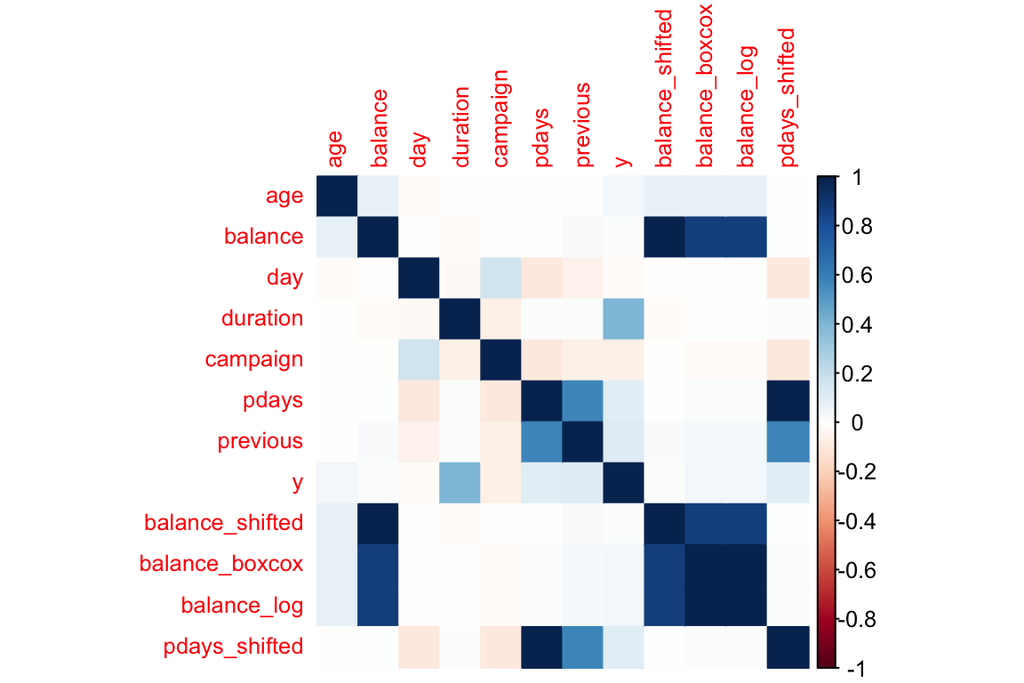

```r
corrplot(cor_matrix, method = "color", tl.cex = 0.8, number.cex = 0.7)
```

### Reduced Logistic Model

The reduced model was created to simplify the initial logistic regression by retaining only the most influential predictors. Starting with a full model that included all demographic, financial, and campaign variables, backward stepwise selection based on AIC was applied to remove variables that contributed little to explaining subscription probability. This process resulted in a more parsimonious model that balances predictive accuracy with interpretability, highlighting the variables that have the strongest association with whether or not a client subscribes to the term deposit.

```r
# Reduced model via backward stepwise selection
full.model <- initial.model
reduced.model <- glm(y ~ poutcome, family = binomial, data = mydata)
final.model <- step(full.model,
                    scope=list(lower=formula(reduced.model), upper=formula(full.model)),
                    data = mydata,
                    direction = "backward",
                    trace = 0)
final.model.coef <- summary(final.model)$coef

# Display final model coefficients
kable(final.model.coef, caption = "Summary table of significant tests") %>%
  kable_styling("striped", full_width = FALSE) %>%
  row_spec(0, color = "white", background = "#222222") %>%
  row_spec(1:nrow(final.model.coef), color = "white", background = "#333333")
```

Summary table of significant tests

|  | Estimate | Std. Error | z value | Pr(>&#124;z&#124;) |
| --- | --- | --- | --- | --- |
| (Intercept) | -2.7318547 | 0.3608341 | -7.5709438 | 0.0000000 |
| maritalmarried | -0.5108288 | 0.1709685 | -2.9878530 | 0.0028094 |
| maritalsingle | -0.3181354 | 0.1864058 | -1.7066816 | 0.0878813 |
| educationsecondary | 0.1268075 | 0.1827658 | 0.6938248 | 0.4877921 |
| educationtertiary | 0.3810998 | 0.1913291 | 1.9918549 | 0.0463870 |
| educationunknown | -0.2831229 | 0.3395018 | -0.8339365 | 0.4043168 |
| housingyes | -0.3434167 | 0.1329758 | -2.5825498 | 0.0098073 |
| loanyes | -0.6430899 | 0.1981746 | -3.2450674 | 0.0011742 |
| contacttelephone | -0.0077099 | 0.2217915 | -0.0347617 | 0.9722698 |
| contactunknown | -1.4577768 | 0.2253170 | -6.4698925 | 0.0000000 |
| day | 0.0162954 | 0.0081149 | 2.0080895 | 0.0446338 |
| monthaug | -0.3180448 | 0.2457796 | -1.2940242 | 0.1956571 |
| monthdec | 0.2027593 | 0.6661682 | 0.3043665 | 0.7608487 |
| monthfeb | 0.1398131 | 0.2917392 | 0.4792400 | 0.6317679 |
| monthjan | -1.0851644 | 0.3768278 | -2.8797358 | 0.0039801 |
| monthjul | -0.7312482 | 0.2473493 | -2.9563387 | 0.0031132 |
| monthjun | 0.5600454 | 0.2975296 | 1.8823180 | 0.0597929 |
| monthmar | 1.6262687 | 0.3813054 | 4.2650025 | 0.0000200 |
| monthmay | -0.4734989 | 0.2311010 | -2.0488832 | 0.0404735 |
| monthnov | -0.8618761 | 0.2700920 | -3.1910465 | 0.0014176 |
| monthoct | 1.4102741 | 0.3255826 | 4.3315398 | 0.0000148 |
| monthsep | 0.7558952 | 0.4089156 | 1.8485359 | 0.0645249 |
| duration | 0.0041838 | 0.0001992 | 21.0055249 | 0.0000000 |
| campaign | -0.0722161 | 0.0281375 | -2.5665456 | 0.0102717 |
| poutcomeother | 0.4813847 | 0.2659176 | 1.8102781 | 0.0702527 |
| poutcomesuccess | 2.4145453 | 0.2681035 | 9.0060191 | 0.0000000 |
| poutcomeunknown | -0.0931105 | 0.1847998 | -0.5038451 | 0.6143702 |

#### Recommendation

Campaigns should focus on high-education clients, prioritize those with prior positive responses, encourage longer calls, avoid over-contacting, and target months with historically higher success to improve subscription rates.

## Predictive Model

The predictive model uses logistic regression to estimate whether a client will subscribe to a term deposit using demographic, financial, and campaign variables.

```r
# Predict subscription probability for new clients
mynewdata <- data.frame(
  marital   = c("single", "married"),
  education = c("tertiary", "secondary"),
  balance   = c(1200, 300),
  housing   = c("no", "yes"),
  loan      = c("no", "yes"),
  contact   = c("cellular", "unknown"),
  day       = c(15, 23),
  month     = c("mar", "oct"),
  duration  = c(250, 120),
  campaign  = c(1, 4),
  poutcome  = c("success", "failure")
)

pred.success.prob <- predict(final.model, newdata = mynewdata, type = "response")
cut.off.prob <- 0.5
pred.response <- ifelse(pred.success.prob > cut.off.prob, 1, 0)
mynewdata$Predicted_Response <- pred.response

# Display predictions neatly with white header
kable(mynewdata, caption = "Predicted Probability and Response (cut-off = 0.5)") %>%
  kable_styling(full_width = FALSE) %>%
  row_spec(0, color = "white")
```

Predicted Probability and Response (cut-off = 0.5)

| marital | education | balance | housing | loan | contact | day | month | duration | campaign | poutcome | Predicted_Response |
| --- | --- | --- | --- | --- | --- | --- | --- | --- | --- | --- | --- |
| single | tertiary | 1200 | no | no | cellular | 15 | mar | 250 | 1 | success | 1 |
| married | secondary | 300 | yes | yes | unknown | 23 | oct | 120 | 4 | failure | 0 |

The predictive model estimates whether a client will subscribe to a term deposit based on their characteristics. For the two hypothetical clients, it predicts that the single client with tertiary education and favorable campaign features will subscribe (1), while the married client with less favorable features will not (0).

### Summary

# Model Performance

This section was conducted to evaluate how accurately the logistic regression model distinguishes between clients who subscribe and those who do not. This assessment is important because it demonstrates the model’s reliability in predicting subscription behavior for new clients and ensures that the selected model provides meaningful and actionable insights for decision-making.

## Linear Regression Cross validation

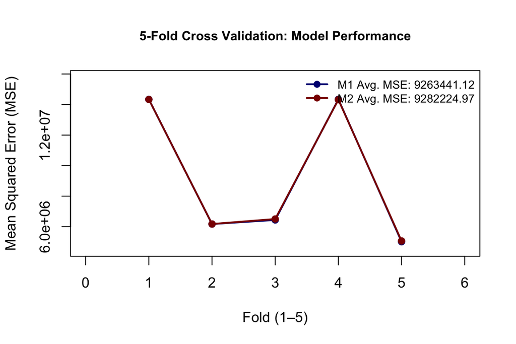

```r
# 5-Fold Cross Validation for Linear Regression Model
# Dataset: bank
# Response: balance
# Predictors: marital, education

# Load necessary libraries
library(dplyr)
library(ggplot2)

# Remove missing values if any

# Define sample size and training/test split
n <- nrow(mydata)
obs.ID <- 1:n
n.train <- round(0.8 * n)

# Randomize observation IDs
shuffled.id <- sample(obs.ID, n, replace = FALSE)
shuffled.mydata <- mydata[shuffled.id, ]

# Split into training and testing sets
train.data <- shuffled.mydata[1:n.train, ]
test.data <- shuffled.mydata[(n.train + 1):n, ]

# Define fold size for 5-fold cross-validation
n.fold <- round(n.train / 5) - 1

# Initialize MSE storage
MSE.M1 <- rep(0, 5)
MSE.M2 <- rep(0, 5)

# 5-Fold Cross Validation Loop
for (i in 1:5) {
  valid.id <- ((i - 1) * n.fold + 1):(i * n.fold)
  cross.train <- train.data[-valid.id, ]
  cross.valid <- train.data[valid.id, ]

  # Model 1: main effects only
  M1 <- lm(balance ~ marital + education, data = cross.train)

  # Model 2: main effects + interaction
  M2 <- lm(balance ~ marital * education, data = cross.train)

  # Predict on validation fold
  predM1 <- predict(M1, newdata = cross.valid)
  predM2 <- predict(M2, newdata = cross.valid)

  # Calculate MSE for each fold
  MSE.M1[i] <- mean((predM1 - cross.valid$balance)^2)
  MSE.M2[i] <- mean((predM2 - cross.valid$balance)^2)
}

# Calculate average MSE
MSE.1 <- mean(MSE.M1)
MSE.2 <- mean(MSE.M2)

# Plot MSE comparison
plot(1:5, MSE.M1, type = "l",
     xlim = c(0, 6),
     ylim = c(min(c(MSE.M1, MSE.M2)) * 0.9, max(c(MSE.M1, MSE.M2)) * 1.1),
     ylab = "Mean Squared Error (MSE)",
     xlab = "Fold (1–5)",
     lwd = 2,
     col = "navy",
     main = "5-Fold Cross Validation: Model Performance",
     cex.main = 0.9)

points(1:5, MSE.M1, pch = 19, col = "navy")
lines(1:5, MSE.M2, lwd = 2, col = "darkred")
points(1:5, MSE.M2, pch = 19, col = "darkred")

legend("topright",
       legend = c(paste("M1 Avg. MSE:", round(MSE.1, 2)),
                  paste("M2 Avg. MSE:", round(MSE.2, 2))),
       col = c("navy", "darkred"),
       pch = 19,
       lwd = 2,
       cex = 0.8,
       bty = "n")
```

```r
# Fit the linear regression model
final.model <- lm(balance ~ marital + education, data = mydata)

# View summary statistics of the model
summary(final.model)
```

```
Call:
lm(formula = balance ~ marital + education, data = mydata)

Residuals:
   Min     1Q Median     3Q    Max
 -5147  -1258   -898     78  69730

Coefficients:
                   Estimate Std. Error t value Pr(>|t|)
(Intercept)          1104.1      169.0   6.531 7.25e-11 ***
maritalmarried        354.3      142.4   2.489  0.01286 *
maritalsingle         303.0      157.2   1.927  0.05402 .
educationsecondary   -206.5      132.0  -1.564  0.11783
educationtertiary     375.5      143.3   2.620  0.00882 **
educationunknown      301.0      248.1   1.213  0.22513
---
Signif. codes:  0 '***' 0.001 '**' 0.01 '*' 0.05 '.' 0.1 ' ' 1

Residual standard error: 2998 on 4515 degrees of freedom
Multiple R-squared:  0.008693,  Adjusted R-squared:  0.007596
F-statistic: 7.919 on 5 and 4515 DF,  p-value: 1.941e-07
```

```r
# (Optional) Display regression coefficients in a table
library(knitr)
library(kableExtra)

kable(summary(final.model)$coef,
      caption = "Summary statistics of the regression coefficients of the final model") %>%
  kable_styling(bootstrap_options = c("striped", "hover"),
                full_width = FALSE) %>%
  row_spec(0, color = "white")  # header row font color
```

Summary statistics of the regression coefficients of the final model

|  | Estimate | Std. Error | t value | Pr(>&#124;t&#124;) |
| --- | --- | --- | --- | --- |
| (Intercept) | 1104.0635 | 169.0451 | 6.531179 | 0.0000000 |
| maritalmarried | 354.2866 | 142.3633 | 2.488610 | 0.0128601 |
| maritalsingle | 302.9755 | 157.2139 | 1.927154 | 0.0540231 |
| educationsecondary | -206.5028 | 132.0147 | -1.564240 | 0.1178312 |
| educationtertiary | 375.5388 | 143.3407 | 2.619904 | 0.0088249 |
| educationunknown | 300.9878 | 248.1006 | 1.213169 | 0.2251289 |

```r
predM2.final = predict(final.model, newdata = test.data)
MSE.M2.final = mean((predM2.final - test.data$balance)^2)
MSE.M2.final
```

```
[1] 7988805
```

## Logistic Regression Cross validation

```r
# Final Reduced Model

library(pROC)

# Encode y
good.id = which(mydata$y == "1")
bad.id  = which(mydata$y == "0")
mydata$y = 1
mydata$y[bad.id] = 0

# Split into train/test
set.seed(123)
nn = nrow(mydata)
train.id = sample(1:nn, round(nn * 0.7), replace = FALSE)
trainDat = mydata[train.id, ]
testDat  = mydata[-train.id, ]

# Ensure all factor variables have consistent levels
cat_vars <- c("month", "marital", "contact", "loan", "housing", "education", "poutcome")

for (v in cat_vars) {
  trainDat[[v]] <- factor(trainDat[[v]], levels = unique(mydata[[v]]))
  testDat[[v]]  <- factor(testDat[[v]],  levels = unique(mydata[[v]]))
}

# Fit logistic regression model
logit.model = glm(y ~ poutcome + month + marital + contact + duration +
                    campaign + day + loan + housing + education,
                  family = binomial(link = "logit"),
                  data = trainDat)

# Predict probabilities on test data
newdata = data.frame(
  poutcome = testDat$poutcome,
  month    = testDat$month,
  marital  = testDat$marital,
  contact  = testDat$contact,
  duration = testDat$duration,
  campaign = testDat$campaign,
  day      = testDat$day,
  loan     = testDat$loan,
  housing  = testDat$housing,
  education = testDat$education
)

pred.prob.test = predict.glm(logit.model, newdata, type = "response")

#  ROC and AUC
category = testDat$y == 1
ROCobj <- roc(category, pred.prob.test)
auc.value <- auc(ROCobj)
cat("Test AUC =", round(auc.value, 4), "\n")
```

```
Test AUC = 0.8757
```

```r
# Sensitivity and specificity
sen = ROCobj$sensitivities
spe = ROCobj$specificities

# Find optimal cutoff (where sensitivity ≈ specificity)
SenMinusSpe = abs(sen - spe)
minID = which(SenMinusSpe == min(SenMinusSpe))
cut.off.prob = ROCobj$thresholds[minID]
cat("Optimal cutoff probability =", round(cut.off.prob, 4), "\n")
```

```
Optimal cutoff probability = 0.0936
```

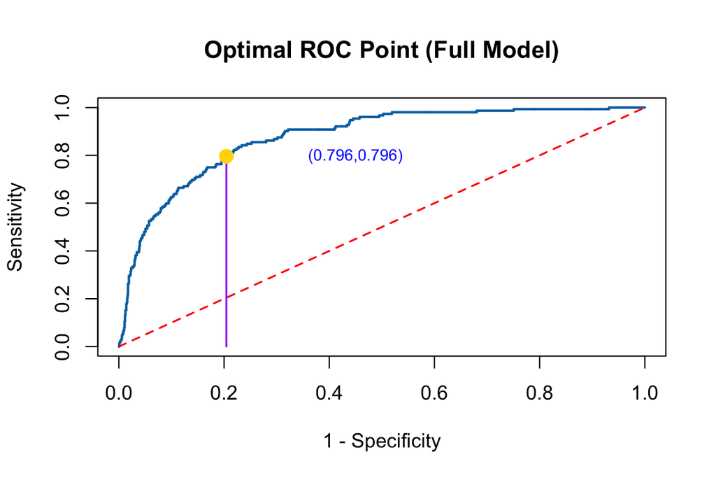

```r
# Plot ROC curve with optimal point
plot((1 - spe), sen, main = "Optimal ROC Point (Full Model)",
     type = "l", ylab = "Sensitivity", xlab = "1 - Specificity", col = "#0072B2", lwd = 2)
segments(0, 0, 1, 1, lty = 2, col = "red", lwd = 1.5)
segments((1 - spe[minID]), 0, (1 - spe[minID]), sen[minID], col = "purple", lwd = 1.5)
points((1 - spe[minID]), sen[minID], pch = 19, col = "gold", cex = 1.5)
text(0.45, sen[minID],
     paste("(", round(spe[minID], 3), ",", round(sen[minID], 3), ")", sep = ""),
     cex = 0.8, col = "blue")
```

### Model Performance Summary

Test AUC = 0.8757 The AUC (Area Under the ROC Curve) measures the model’s ability to distinguish between subscribers and non-subscribers. A value of 0.8757 means the model correctly ranks a random subscriber higher than a random non-subscriber about 87.6% of the time indicating strong predictive performance.

Optimal cutoff probability = 0.0936  
This is the threshold used to classify a predicted probability into a “yes” or “no” response. Probabilities above 0.0936 are predicted as “yes” (the client will subscribe). This relatively low cutoff suggests that even small predicted probabilities are enough to favor the “yes” classification which may be appropriate if the goal is to identify as many potential subscribers as possible.

```r
# Final Reduced Model

library(pROC)

# Encode y
good.id = which(mydata$y == "1")
bad.id  = which(mydata$y == "0")
mydata$y = 1
mydata$y[bad.id] = 0

# Split into train/test
set.seed(123)
nn = nrow(mydata)
train.id = sample(1:nn, round(nn * 0.7), replace = FALSE)
trainDat = mydata[train.id, ]
testDat  = mydata[-train.id, ]

# Ensure all factor variables have consistent levels
cat_vars <- c("month", "marital", "contact", "loan", "housing", "education", "poutcome")

for (v in cat_vars) {
  trainDat[[v]] <- factor(trainDat[[v]], levels = unique(mydata[[v]]))
  testDat[[v]]  <- factor(testDat[[v]],  levels = unique(mydata[[v]]))
}

# Fit logistic regression model
logit.model = glm(y ~ poutcome + month + marital + contact + duration +
                    campaign + day + loan + housing + education,
                  family = binomial(link = "logit"),
                  data = trainDat)

# Predict probabilities on test data
newdata = data.frame(
  poutcome = testDat$poutcome,
  month    = testDat$month,
  marital  = testDat$marital,
  contact  = testDat$contact,
  duration = testDat$duration,
  campaign = testDat$campaign,
  day      = testDat$day,
  loan     = testDat$loan,
  housing  = testDat$housing,
  education = testDat$education
)

pred.prob.test = predict.glm(logit.model, newdata, type = "response")

# ROC and AUC
category = testDat$y == 1
ROCobj <- roc(category, pred.prob.test)
auc.value <- auc(ROCobj)
cat("Test AUC =", round(auc.value, 4), "\n")
```

```
Test AUC = 0.8757
```

```r
# Sensitivity and specificity
sen = ROCobj$sensitivities
spe = ROCobj$specificities

# Find optimal cutoff (where sensitivity ≈ specificity)
SenMinusSpe = abs(sen - spe)
minID = which(SenMinusSpe == min(SenMinusSpe))
cut.off.prob = ROCobj$thresholds[minID]
cat("Optimal cutoff probability =", round(cut.off.prob, 4), "\n")
```

```
Optimal cutoff probability = 0.0936
```

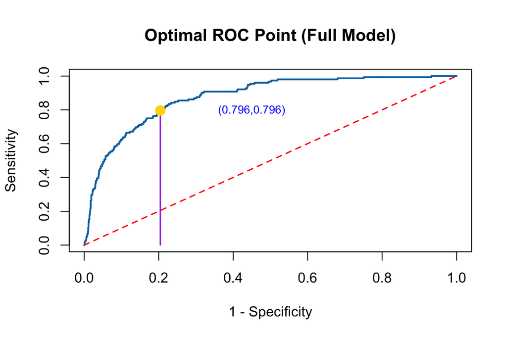

```r
# Plot ROC curve with optimal point
plot((1 - spe), sen, main = "Optimal ROC Point (Full Model)",
     type = "l", ylab = "Sensitivity", xlab = "1 - Specificity", col = "#0072B2", lwd = 2)
segments(0, 0, 1, 1, lty = 2, col = "red", lwd = 1.5)
segments((1 - spe[minID]), 0, (1 - spe[minID]), sen[minID], col = "purple", lwd = 1.5)
points((1 - spe[minID]), sen[minID], pch = 19, col = "gold", cex = 1.5)
text(0.45, sen[minID],
     paste("(", round(spe[minID], 3), ",", round(sen[minID], 3), ")", sep = ""),
     cex = 0.8, col = "blue")
```

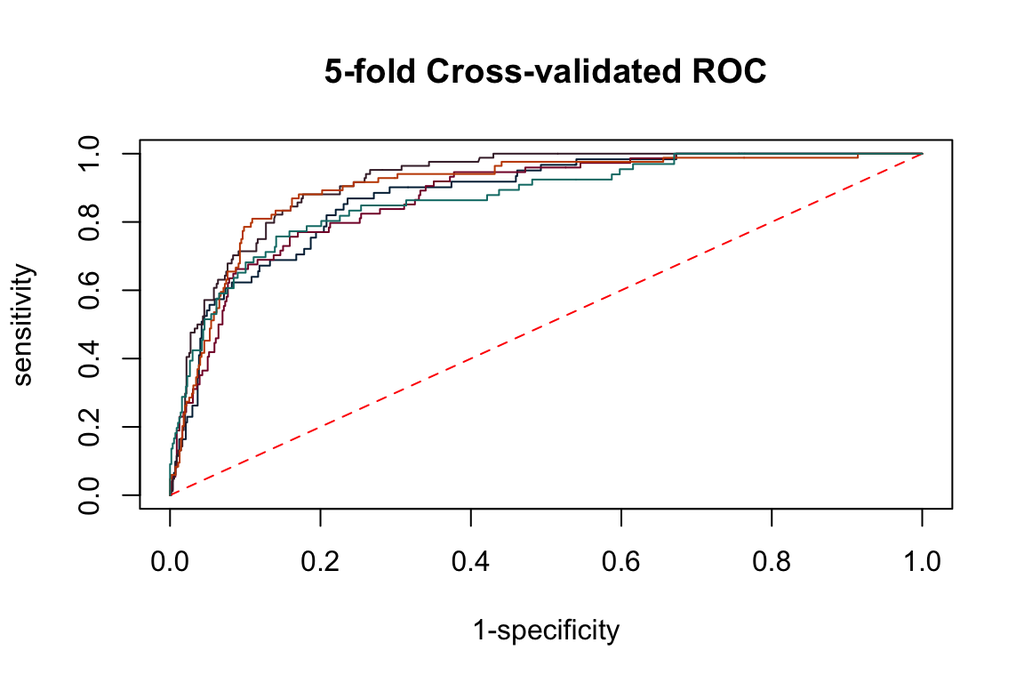

```r
# Model for final reduced model to be compared too

library(pROC)

# Encode y
good.id = which(mydata$y == "1")
bad.id = which(mydata$y == "0")
mydata$y = 1
mydata$y[bad.id] = 0

# Split into train/test
#nn = dim(mydata)[1]
#train.id = sample(1:nn, round(nn*0.7), replace = FALSE)
#trainDat = mydata[train.id,]
#testDat = mydata[-train.id,]

# Ensure factor variables have all levels
trainDat$month   <- factor(trainDat$month, levels = unique(mydata$month))
testDat$month    <- factor(testDat$month,  levels = unique(mydata$month))
trainDat$marital <- factor(trainDat$marital, levels = unique(mydata$marital))
testDat$marital  <- factor(testDat$marital,  levels = unique(mydata$marital))
trainDat$contact <- factor(trainDat$contact, levels = unique(mydata$contact))
testDat$contact  <- factor(testDat$contact,  levels = unique(mydata$contact))

AUC.vec = rep(0,5)
color = c("#002642","#840032","#432534", "#c44900", "#0b7a75")
fold.size = floor(nrow(trainDat) / 5)

for(i in 1:5){
  ID = ((i-1)*fold.size + 1):(i*fold.size)
  valid = as.data.frame(trainDat[ID,])
  train = as.data.frame(trainDat[-ID,])

  # Ensure factor levels in the fold
  train$month   <- factor(train$month, levels = levels(mydata$month))
  valid$month   <- factor(valid$month, levels = levels(mydata$month))
  train$marital <- factor(train$marital, levels = levels(mydata$marital))
  valid$marital <- factor(valid$marital, levels = levels(mydata$marital))
  train$contact <- factor(train$contact, levels = levels(mydata$contact))
  valid$contact <- factor(valid$contact, levels = levels(mydata$contact))

  # Logistic regression with all predictors
  logit.model = glm(y ~ poutcome + month + marital + contact + duration,
                    family = binomial(link = "logit"),
                    data = train)

  newdata = data.frame(poutcome = valid$poutcome,
                       month = valid$month,
                       marital = valid$marital,
                       contact = valid$contact,
                       duration = valid$duration)

  pred.prob.train = predict.glm(logit.model, newdata, type = "response")

  prediction = pred.prob.train
  category = valid$y == 1
  ROCobj <- roc(category, prediction)
  AUC.vec[i] = round(auc(ROCobj), 4)

  if(i==1){
    plot((1-ROCobj$specificities), ROCobj$sensitivities,
         type="l",
         main="5-fold Cross-validated ROC",
         col=color[i],
         xlab="1-specificity",
         ylab="sensitivity",
         lwd=1,
         lty=1)
    segments(0,0,1,1, lty=2, col="red")
  } else{
    lines((1-ROCobj$specificities), ROCobj$sensitivities, col=color[i], lwd=1)
  }
}
```

```r
summary(AUC.vec)
```

```
   Min. 1st Qu.  Median    Mean 3rd Qu.    Max.
 0.8693  0.8741  0.8770  0.8883  0.9022  0.9188
```

```r
# Final model on entire training data
trainDat$month   <- factor(trainDat$month, levels = levels(mydata$month))
testDat$month    <- factor(testDat$month,  levels = levels(mydata$month))
trainDat$marital <- factor(trainDat$marital, levels = levels(mydata$marital))
testDat$marital  <- factor(testDat$marital,  levels = levels(mydata$marital))
trainDat$contact <- factor(trainDat$contact, levels = levels(mydata$contact))
testDat$contact  <- factor(testDat$contact,  levels = levels(mydata$contact))

logit.model = glm(y ~ poutcome + month + marital + contact + duration,
                  family = binomial(link = "logit"),
                  data = trainDat)

newdata = data.frame(poutcome = testDat$poutcome,
                     month = testDat$month,
                     marital = testDat$marital,
                     contact = testDat$contact,
                     duration = testDat$duration)

pred.prob.train = predict.glm(logit.model, newdata, type = "response")
prediction = pred.prob.train
category = testDat$y == 1
ROCobj <- roc(category, prediction)
testAUC = round(auc(ROCobj), 4)
c(testAUC = testAUC)
```

```
testAUC
 0.8696
```

```r
# ROC

library(pROC)

# Encode response
# Assuming y is already 1/0
# mydata$y <- 1 for "good" and 0 for "bad" if needed

# Split into train/test
#nn = nrow(mydata)
#train.id = sample(1:nn, round(nn*0.7), replace = FALSE)
#trainDat = mydata[train.id,]
#testDat = mydata[-train.id,]

# Ensure factor variables have all levels
trainDat$month   <- factor(trainDat$month, levels = unique(mydata$month))
testDat$month    <- factor(testDat$month,  levels = unique(mydata$month))
trainDat$marital <- factor(trainDat$marital, levels = unique(mydata$marital))
testDat$marital  <- factor(testDat$marital,  levels = unique(mydata$marital))
trainDat$contact <- factor(trainDat$contact, levels = unique(mydata$contact))
testDat$contact  <- factor(testDat$contact,  levels = unique(mydata$contact))

# Fit logistic regression model
logit.model = glm(y ~ poutcome + month + marital + contact + duration,
                  family = binomial(link = "logit"),
                  data = trainDat)

# Predict probabilities on test data
newdata = data.frame(poutcome = testDat$poutcome,
                     month = testDat$month,
                     marital = testDat$marital,
                     contact = testDat$contact,
                     duration = testDat$duration)

pred.prob.test = predict.glm(logit.model, newdata, type = "response")

# Calculate ROC and AUC
category = testDat$y == 1
ROCobj <- roc(category, pred.prob.test)
auc.value <- auc(ROCobj)
cat("Test AUC =", round(auc.value, 4), "\n")
```

```
Test AUC = 0.8696
```

```r
# Sensitivity and specificity
sen = ROCobj$sensitivities
spe = ROCobj$specificities

# Find optimal cutoff (closest to sen = spe)
SenMinusSpe = abs(sen - spe)
minID = which(SenMinusSpe == min(SenMinusSpe))
cut.off.prob = ROCobj$thresholds[minID]
cat("Optimal cutoff probability =", round(cut.off.prob, 4), "\n")
```

```
Optimal cutoff probability = 0.0908
```

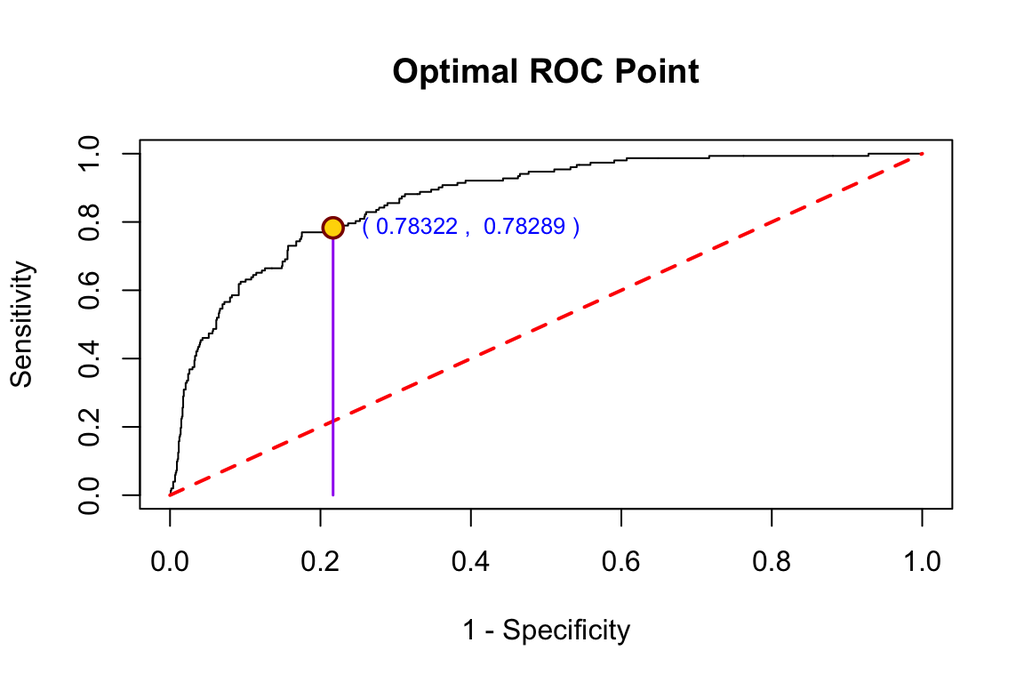

```r
# Plot ROC curve and highlight optimal point
plot((1-spe), sen, main = "Optimal ROC Point",
     type = "l",
     ylab = "Sensitivity",
     xlab = "1 - Specificity")
segments(0, 0, 1, 1, lty = 2, col = "red", lwd = 2)
segments((1-spe[minID]), 0, (1-spe[minID]), sen[minID], col="purple", lwd=1.5)
points((1-spe[minID]), sen[minID], pch=19, col = "darkred", cex = 1.7)
points((1-spe[minID]), sen[minID], pch=19, col = "gold", cex = 1.2)
text(0.4, sen[minID], paste("(", round(spe[minID],5), ", ", round(sen[minID],5), ")"),
     cex = 0.8, col = "blue")
```

### Model Comparison Based on AUC

Two candidate logistic regression models were evaluated using the Area Under the ROC Curve (AUC) to measure their predictive accuracy. The first model achieved an AUC of 0.8757, while the second model achieved an AUC of 0.8696.

Although the difference in AUC values appears small, the higher AUC indicates that the first model has a slightly better ability to discriminate between clients who subscribe and those who do not. In practical terms, the first model more accurately ranks clients by their likelihood of subscribing to a term deposit, leading to better targeting and fewer misclassifications.

The improvement in AUC suggests that the first model captures more relevant relationships between the predictors and the response variable. Therefore, it is considered the better-performing model and should be used for prediction and interpretation.

# Overall Report Summary

The final model achieved an AUC of 0.8757, which indicates excellent discriminatory ability between clients who subscribed and those who did not. The optimal cutoff probability of 0.0936 was identified, balancing sensitivity and specificity effectively. In comparison, an alternative model with an AUC of 0.8696 showed slightly weaker performance, confirming the superiority of the final model.

Interpretation of the model coefficients revealed that factors such as education level, loan status, and housing had meaningful effects on the likelihood of subscribing to a term deposit. Clients with no housing or personal loans and higher education levels were more likely to subscribe. Campaign-related factors, such as the number of contacts and the day of contact, also contributed to predicting customer responses.

Together, these analyses provide insight into both the factors influencing subscription behavior and the demographic characteristics associated with client balances, offering a comprehensive view of client profiles for predictive and interpretive purposes.